# task1

Luwei Lei

10/15/2020

##### Explore all accounts. Create visualizations that combine or these account characteristics:

- an account has a credit card or not
- Whether an account has a loan or not
- The average balance for the account

#### R solution

```r
library(ggplot2)
library(plyr)

#read data
accounts  = read.csv('data/accounts_analytical.csv', header = TRUE)
transactions = read.csv('data/transactions.csv', header = TRUE)
```

```r
#contruct new dataframe for graph
new_df = accounts[c('account_id', 'credit_cards', 'loan_date')]
avg_balance =c()
for (i in unique(accounts$account_id)){
  avg_balance = c(avg_balance, mean(transactions[transactions$account_id == i, 'balance']))
}
new_df$avg_balance = avg_balance
```

```r
#data pre-processing
new_df$credit_cards <- as.character(new_df$credit_cards)
new_df$credit_cards[!is.na(new_df$credit_cards)] <- TRUE
new_df$credit_cards[is.na(new_df$credit_cards)] <- FALSE

names(new_df)[names(new_df) == "loan_date"] <- "loan"
new_df$loan <- as.character(new_df$loan)
new_df$loan[new_df$loan != ""] <- TRUE
new_df$loan[new_df$loan == ""] <- FALSE
```

```r
#histogram by credit cards
#counts
mu1 <- ddply(new_df, "credit_cards", summarise, grp.mean=mean(avg_balance))

p1 <- ggplot(new_df, aes(x=avg_balance, fill=credit_cards, color = credit_cards)) +
      geom_histogram(alpha=.4, position="identity", bins=30) +
      geom_vline(data=mu1, aes(xintercept=grp.mean, color=credit_cards),
               linetype="dashed") +
      labs(title="Histogram of Avg Balance by CC",x="Average Balance", y = "Counts" )

# density plot
p2 <- ggplot(new_df, aes(x=avg_balance, color=credit_cards, fill=credit_cards)) +
  geom_histogram(aes(y=..density..), position="identity", alpha=0.3, bins=30)+
  geom_density(alpha=0.3)+
  geom_vline(data=mu1, aes(xintercept=grp.mean, color=credit_cards),
             linetype="dashed")+
  labs(title="Density of Avg Balance by CC",x="Average Balance", y = "Density")
```

```r
#histogram by loan
#counts
mu2 <- ddply(new_df, "loan", summarise, grp.mean=mean(avg_balance))

p3 <- ggplot(new_df, aes(x=avg_balance, fill=loan, color = loan)) +
      geom_histogram(alpha=.4, position="identity", bins=30) +
      geom_vline(data=mu2, aes(xintercept=grp.mean, color=loan),
               linetype="dashed") +
      labs(title="Histogram of Avg Balance by Loan",x="Average Balance", y = "Counts" )


p4 <- ggplot(new_df, aes(x=avg_balance, color=loan, fill=loan)) +
    geom_histogram(aes(y=..density..), position="identity", alpha=0.3, bins=30)+
    geom_density(alpha=0.3)+
    geom_vline(data=mu2, aes(xintercept=grp.mean, color=loan),
               linetype="dashed")+
    labs(title="Density of Avg Balance by Loan",x="Average Balance", y = "Density")
```

```r
#helper function
multiplot <- function(..., plotlist=NULL, file, cols=1, layout=NULL) {
  library(grid)

  # Make a list from the ... arguments and plotlist
  plots <- c(list(...), plotlist)

  numPlots = length(plots)

  # If layout is NULL, then use 'cols' to determine layout
  if (is.null(layout)) {
    # Make the panel
    layout <- matrix(seq(1, cols * ceiling(numPlots/cols)),
                    ncol = cols, nrow = ceiling(numPlots/cols))
  }

 if (numPlots==1) {
    print(plots[[1]])
  } else {
    # Set up the page
    grid.newpage()
    pushViewport(viewport(layout = grid.layout(nrow(layout), ncol(layout))))

    # Make each plot, in the correct location
    for (i in 1:numPlots) {
      # Get the i,j matrix positions of the regions that contain this subplot
      matchidx <- as.data.frame(which(layout == i, arr.ind = TRUE))
      print(plots[[i]], vp = viewport(layout.pos.row = matchidx$row,
                                      layout.pos.col = matchidx$col))
    }
  }
}
```

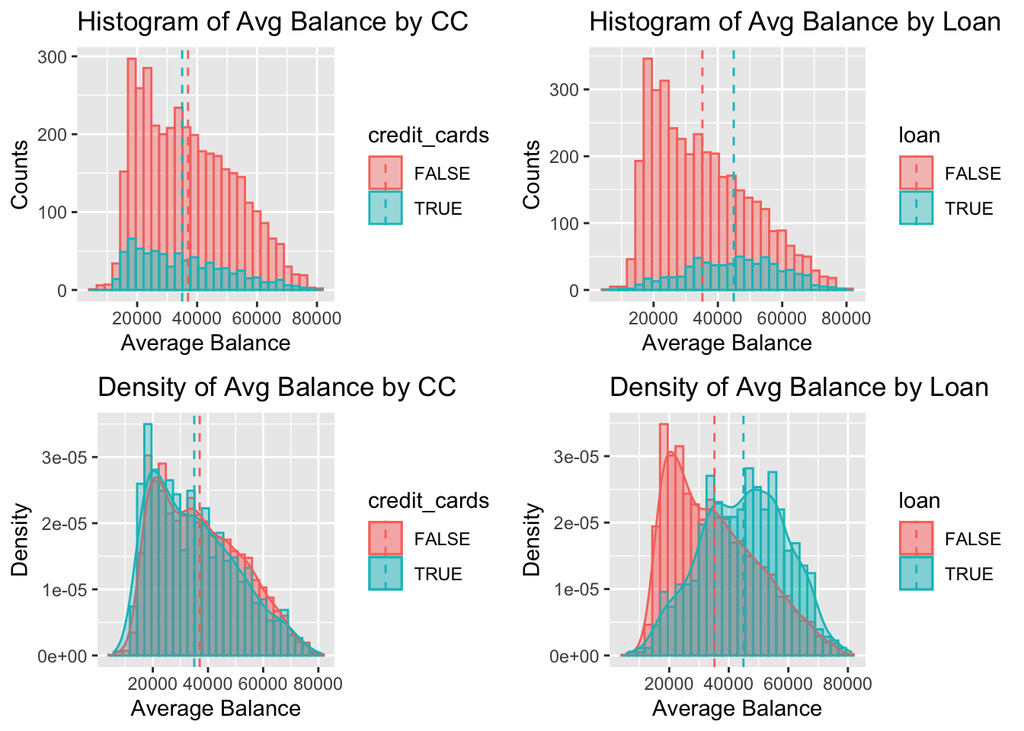

```r
multiplot(p1, p2, p3, p4, cols=2)
```

The above plot is consisted with four subplots which shows the relationship between account average balance and if the user has credit cards or loans repectively. The dash line indicates the mean lines of each distribution. The above two histograms are plotted by counts. It is clearly to see that there are a lot less people have credit cards and loans. The bottom two graphs are density plots. The distributions of users have credit cards or not are very similar. But people with loans have much more average balance than people without loans.

```r
temp = new_df[(new_df$credit_cards == "TRUE") & (new_df$loan == "TRUE"), ]
p11 = ggplot(temp, aes(x=avg_balance)) +
 geom_histogram(colour="#FF6666", fill="white", bins=30)+
 geom_vline(aes(xintercept=mean(avg_balance)), color="#FF6666", linetype="dashed", size=1)+
  labs(title="Avg Balance w/ both CC and loan",x="Average Balance", y = "Counts")

temp = new_df[(new_df$credit_cards == "TRUE") & (new_df$loan == "FALSE"), ]
p22 = ggplot(temp, aes(x=avg_balance)) +
 geom_histogram(colour="#FF6666", fill="white", bins=30)+
 geom_vline(aes(xintercept=mean(avg_balance)), color="#FF6666", linetype="dashed", size=1)+
  labs(title="Avg Balance w/ CC but w/out loan",x="Average Balance", y = "Counts")

temp = new_df[(new_df$credit_cards == "FALSE") & (new_df$loan == "TRUE"), ]
p33 = ggplot(temp, aes(x=avg_balance)) +
 geom_histogram(colour="#FF6666", fill="white", bins=30)+
 geom_vline(aes(xintercept=mean(avg_balance)), color="#FF6666", linetype="dashed", size=1) +
  labs(title="Avg Balance w/ loan cc but w/out cc",x="Average Balance", y = "Counts")

temp = new_df[(new_df$credit_cards == "FALSE") & (new_df$loan == "FALSE"), ]
p44 = ggplot(temp, aes(x=avg_balance)) +
 geom_histogram(colour="#FF6666", fill="white", bins=30)+
 geom_vline(aes(xintercept=mean(avg_balance)), color="#FF6666", linetype="dashed", size=1)+
  labs(title="Avg Balance w/out both cc and loan",x="Average Balance", y = "Counts")
```

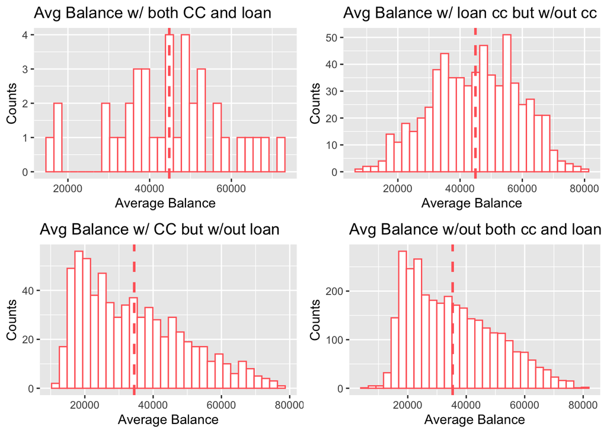

```r
temp = new_df[(new_df$credit_cards == "TRUE") & (new_df$loan == "TRUE"), ]
p1 = ggplot(temp, aes(x=avg_balance)) +
 geom_histogram(aes(y=..density..), colour="#FF6666", fill="white", bins=30)+
 geom_density(alpha=.2, fill="#FF6666") +
 geom_vline(aes(xintercept=mean(avg_balance)), color="#FF6666", linetype="dashed", size=1)+
  labs(title="Avg Balance w/ both cc and loan",x="Average Balance", y = "Density")

temp = new_df[(new_df$credit_cards == "TRUE") & (new_df$loan == "FALSE"), ]
p2 = ggplot(temp, aes(x=avg_balance)) +
 geom_histogram(aes(y=..density..), colour="#FF6666", fill="white", bins=30)+
 geom_density(alpha=.2, fill="#FF6666") +
 geom_vline(aes(xintercept=mean(avg_balance)), color="#FF6666", linetype="dashed", size=1)+
  labs(title="Avg Balance w/ cc but w/out loan",x="Average Balance", y = "Density")

temp = new_df[(new_df$credit_cards == "FALSE") & (new_df$loan == "TRUE"), ]
p3 = ggplot(temp, aes(x=avg_balance)) +
 geom_histogram(aes(y=..density..), colour="#FF6666", fill="white", bins=30)+
 geom_density(alpha=.2, fill="#FF6666") +
 geom_vline(aes(xintercept=mean(avg_balance)), color="#FF6666", linetype="dashed", size=1) +
  labs(title="Avg Balance w/ loan but w/out cc",x="Average Balance", y = "Density")

temp = new_df[(new_df$credit_cards == "FALSE") & (new_df$loan == "FALSE"), ]
p4 = ggplot(temp, aes(x=avg_balance)) +
 geom_histogram(aes(y=..density..), colour="#FF6666", fill="white", bins=30)+
 geom_density(alpha=.2, fill="#FF6666") +
 geom_vline(aes(xintercept=mean(avg_balance)), color="#FF6666", linetype="dashed", size=1)+
  labs(title="Avg Balance w/out both cc and loan",x="Average Balance", y = "Density")

multiplot(p11, p22, p33, p44, cols=2)
```

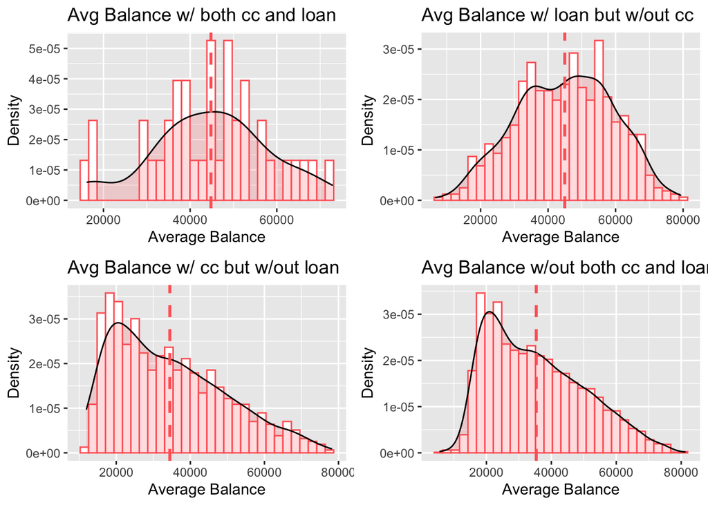

```r
multiplot(p1, p2, p3, p4, cols=2)
```

The above graphs counted in both loan and credit cards status. One thing to notice here is that there are only few acounts have both credit cards and loans. In general, distributions of the accounts without loans are right skewed regardless the credit cards status.